# lab4 Assignment

Somnath Mukherjee

February 12, 2019

### Lab set-up

```r
#read input file
patients = read.table(here('lab4','data','data4.txt'), header = T, sep = " ") #use here() function to specify path
str(patients)
```

```
## 'data.frame':    54 obs. of  6 variables:
##  $ obs : int  1 2 3 4 5 6 7 8 9 10 ...
##  $ clot: num  3.7 8.7 6.7 6.7 3.2 5.2 3.6 5.8 5.7 6 ...
##  $ prog: int  51 45 51 26 64 54 28 38 46 85 ...
##  $ enz : int  41 23 43 68 65 56 99 72 63 28 ...
##  $ liv : num  1.55 2.52 1.86 2.1 0.74 2.71 1.3 1.42 1.91 2.98 ...
##  $ time: int  34 58 65 70 71 72 75 80 80 87 ...
```

### Question 1: Make a scatter plot to show the relationship between TIME and ENZ. What is your observation? How about the scatter plot showing the relationship between Log-Time ( that is the log transform of Time) and ENZ.

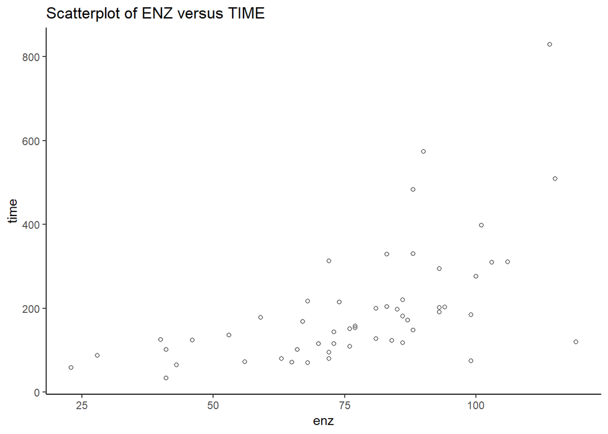

```r
ggplot(data = patients,aes(x = enz,y = time))+
  geom_point(shape=1)+
  ggtitle('Scatterplot of ENZ versus TIME') +
  theme_classic()
```

Based on the scatterplot above the relationship between TIME and ENZ does not seem to be linear, rather curvilinear. It somewhat follows an exponential growth model.

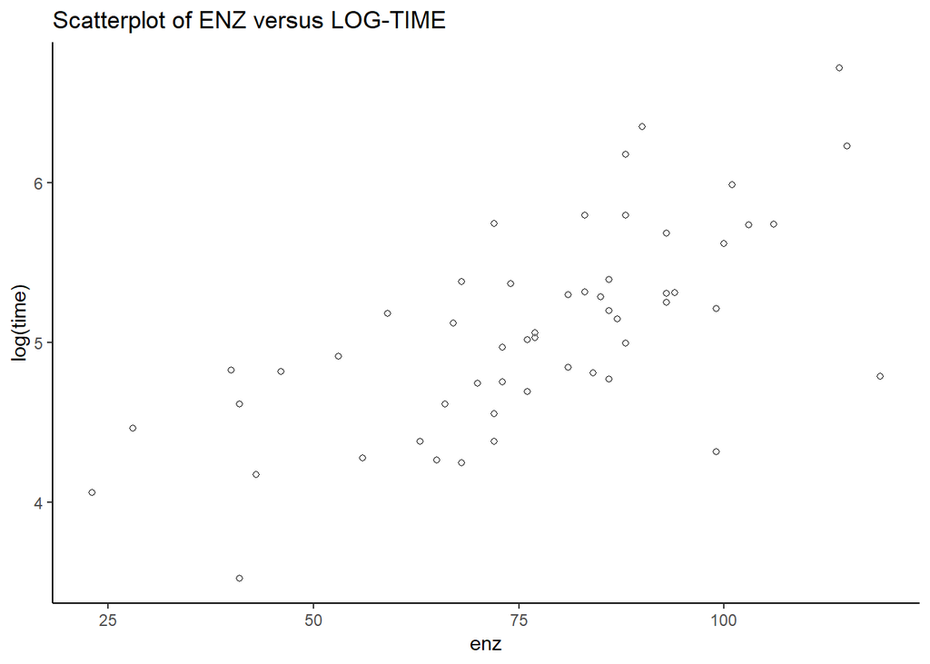

```r
ggplot(data = patients, aes(x = enz,y = log(time)))+
  geom_point(shape = 1)+
  ggtitle('Scatterplot of ENZ versus LOG-TIME')+
  theme_classic()
```

Based on the scatterplot above the relationship between Log-Time and ENZ appears to be linear.

### Question 2: Fit the simple linear regression model TIME = b0 + b1*ENZ + e. Write down the estimated regression function and examine the residual plot and normality test. Describe what you observed and make brief comments.

```r
#' Fit the SLR model, time = B0 + enz (B1) using the lm function
lm_patients <- lm(time ~ enz, data = patients)
summary(lm_patients)
```

```
##
## Call:
## lm(formula = time ~ enz, data = patients)
##
## Residuals:
##     Min      1Q  Median      3Q     Max
## -243.33  -64.74  -25.19   49.45  486.50
##
## Coefficients:
##              Estimate Std. Error t value Pr(>|t|)
## (Intercept) -108.7161    61.7191  -1.761    0.084 .
## enz            3.9668     0.7721   5.137 4.25e-06 ***
## ---
## Signif. codes:  0 '***' 0.001 '**' 0.01 '*' 0.05 '.' 0.1 ' ' 1
##
## Residual standard error: 119.5 on 52 degrees of freedom
## Multiple R-squared:  0.3367, Adjusted R-squared:  0.3239
## F-statistic: 26.39 on 1 and 52 DF,  p-value: 4.25e-06
```

Based on the information above our regression model is:  
TIME(predicted) = -108.71 + 3.96*ENZ  
From the ANOVA table for F-statistic: 26.39 on 1 and 52 DF, p-value: 4.25e-06, which implies b1 is significant(and non-zero) and we have some sort of regression effect.  
However we have a low value for R-squared as 0.3367, which implies that not much of the total variability is explained by the model.  
Moreover, the intercept (-108.71) looks problematic for a non-significant p-value of 0.08. Hence we will check further for the SLR assumptions (normality of residuals and homogenity of variance).

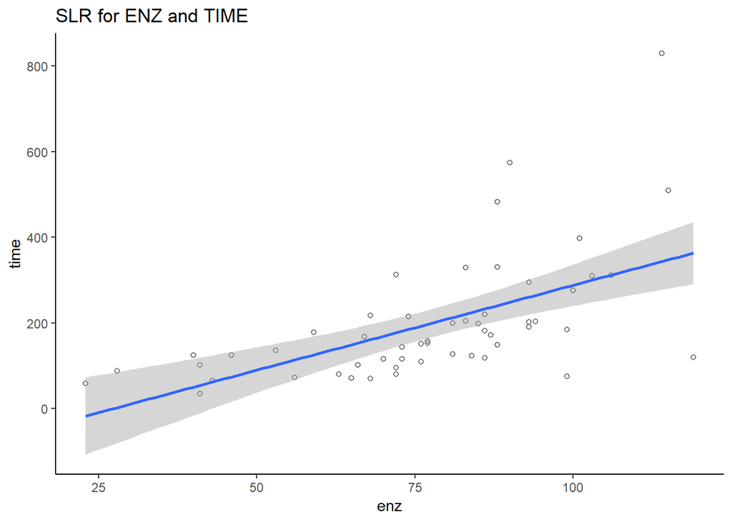

```r
ggplot(data = patients,aes(x = enz,y = time))+
  geom_point(shape=1)+
  geom_smooth(method = lm)+
  ggtitle('SLR for ENZ and TIME') +
  theme_classic()
```

From the plot above we can see some possible outliers and leverage observations. Those will be more clear in the residual plot.  
Residual Plot and Normality test.

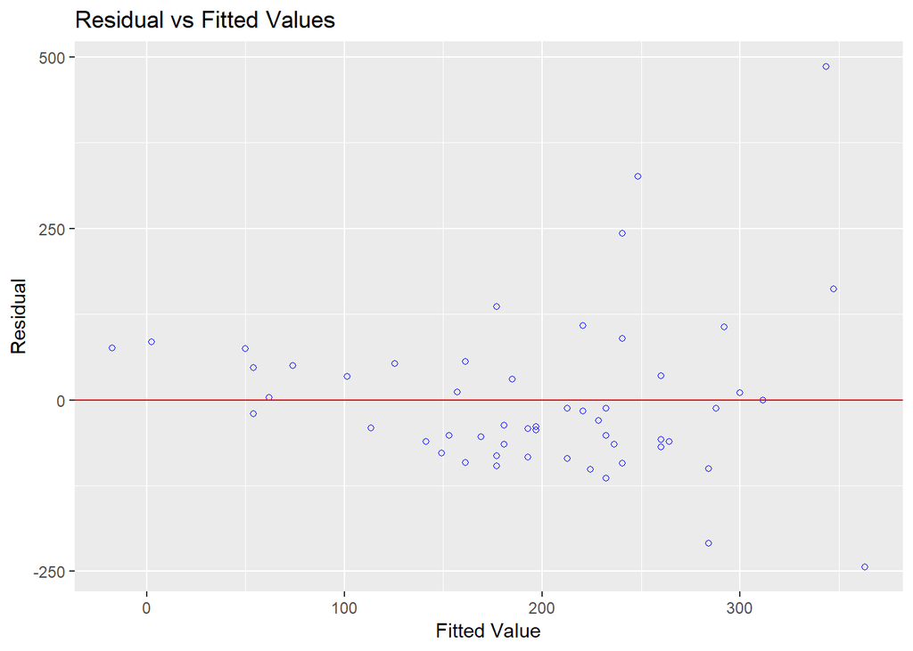

```r
ols_plot_resid_fit(lm_patients)
```

```r
ols_test_normality(lm_patients)
```

```
## -----------------------------------------------
##        Test             Statistic       pvalue
## -----------------------------------------------
## Shapiro-Wilk              0.866          0.0000
## Kolmogorov-Smirnov         0.14          0.2190
## Cramer-von Mises          5.1667         0.0000
## Anderson-Darling          1.9562         0.0000
## -----------------------------------------------
```

The residual plot appears to be fan shaped (fans out in fact) which indicates non-homogeneous variance.  
And from Shapiro-Wilk p-value, we can say that normality of residuals is not preserved.

### Question 3: Fit the exponential model logTIME = b0 + b1ENZ + e. Write down the estimated regression function.Does the model fit well? Why?

```r
#Fit the new model as curvilinear model(intrinsically linear)
log_patients = lm(log(time) ~ enz, data = patients)
summary(log_patients)
```

```
##
## Call:
## lm(formula = log(time) ~ enz, data = patients)
##
## Residuals:
##      Min       1Q   Median       3Q      Max
## -1.19415 -0.29725 -0.02198  0.34125  1.01853
##
## Coefficients:
##             Estimate Std. Error t value Pr(>|t|)
## (Intercept) 3.558633   0.245526  14.494  < 2e-16 ***
## enz         0.019727   0.003072   6.423 4.12e-08 ***
## ---
## Signif. codes:  0 '***' 0.001 '**' 0.01 '*' 0.05 '.' 0.1 ' ' 1
##
## Residual standard error: 0.4753 on 52 degrees of freedom
## Multiple R-squared:  0.4424, Adjusted R-squared:  0.4316
## F-statistic: 41.25 on 1 and 52 DF,  p-value: 4.118e-08
```

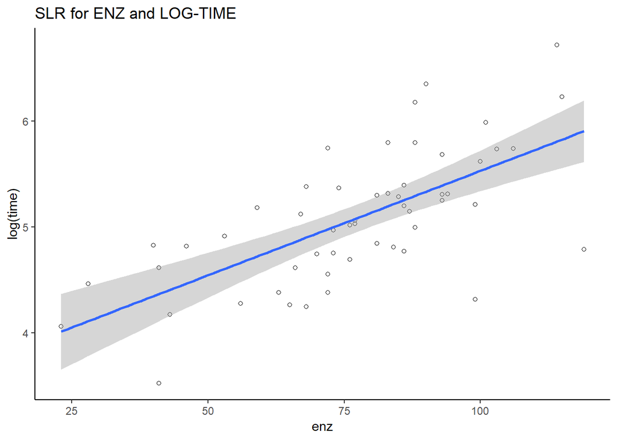

```r
ggplot(data = patients, aes(x = enz,y = log(time)))+
  geom_point(shape = 1)+
  geom_smooth(method = lm)+
  ggtitle('SLR for ENZ and LOG-TIME') +
  theme_classic()
```

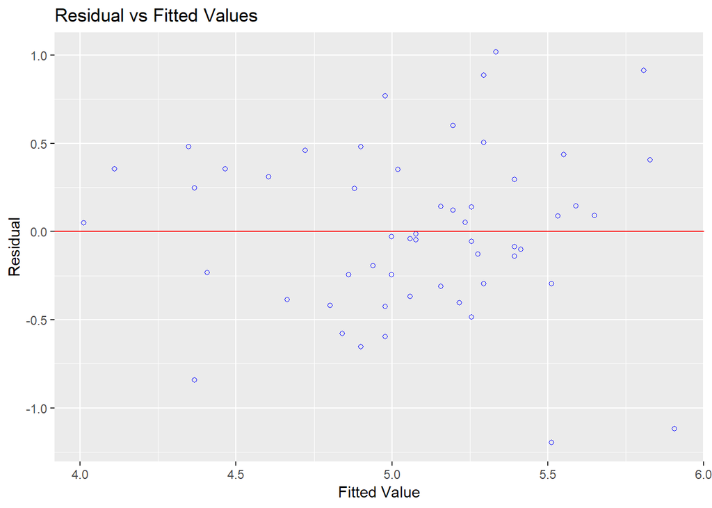

```r
ols_plot_resid_fit(log_patients)
```

```r
ols_test_normality(log_patients)
```

```
## -----------------------------------------------
##        Test             Statistic       pvalue
## -----------------------------------------------
## Shapiro-Wilk              0.9882         0.8716
## Kolmogorov-Smirnov        0.0536         0.9955
## Cramer-von Mises          6.737          0.0000
## Anderson-Darling          0.1673         0.9338
## -----------------------------------------------
```

The residual plot looks much better with random scatter around the zero value. No appearent curvature or shape.  
And from Shapiro-Wilk test (p-value as 0.87) we can assume normality of the residual is preserved.

### Question 4:Compare the simple linear model in Question 1 and the exponential model in Question 2, do you observe any improvements after conducting the exponential model relative to the linear model? Support your conclusion with details (such as R-Square, homogeneity of variance and normality test)

There are clearly some improvement with the curvilinear model (exponential growth model) over the simple linear model and I have already pointed them out during Q2 and Q3.  
We have better R-square and model fit for exponential model.  
For exponential model both homogeneity of variance and normality of residual assumptions are preserved.  
Hence we can conclude that exponential model is a better fit for the given data.